# Проверка статистических гипотез

Морские моллюски: набор данных Abalone

## Требования к сдаче и оформлению задания

Заполните этот qmd-файл кодом и ответами. Порядок сдачи задания описан в README.md, в Google Classroom или на Stepik.

1. Старайтесь соблюдать единый стиль оформления и структуру отчёта. Не оставляйте лишние чанки кода, текст или комментарии, которые не относятся к решению задания.
2. Численные результаты представляйте в тексте или аккуратных таблицах с понятными подписями. Не оставляйте необработанный консольный вывод или отдельные числа без пояснений.
3. Графики должны быть достаточно крупными, с читаемыми русскими подписями, содержательным заголовком и правильно названными осями. Не используйте фон ggplot2 по умолчанию.
4. Ответы на вопросы и интерпретации результатов, включая графики, пишите обычным текстом, а не комментариями к коду. Код и его вывод не заменяют ответ на вопрос.
5. Сохраняйте исходную структуру проекта в репозитории. Не добавляйте лишние файлы, которые не относятся к проекту или выполнению заданий.
6. Оформление коммитов и веток на GitHub должно соответствовать общим правилам для всех курсов Института биоинформатики.

## О задании

- В этом домашнем задании мы будем использовать набор данных **Abalone**, содержащий измерения 4177 морских моллюсков рода *Haliotis*: [Подробнее](https://archive.ics.uci.edu/dataset/1/abalone).
- Вам предстоит проверить три статистические гипотезы: **две – с помощью доверительных интервалов (ДИ), одну – с помощью сравнения тестовой статистики с критическим значением**.
- Во всех заданиях используйте **уровень значимости $\alpha = 0.05$**. Для построения ДИ используйте **95%-й уровень доверия**.
- **Формулируйте выводы в терминах нулевой гипотезы**: мы отклоняем или не отклоняем именно её!

## О данных

Файл `abalone.csv` в директории `data` содержит несколько столбцов-признаков, из которых нам потребуются:

- **`Sex`**: `M` – самцы, `F` – самки, `I` – незрелые особи.
- **`Length`** – длина раковины, мм
- **`Shucked_weight`** – масса съедобной части моллюска после извлечения из раковины, г
- **`Shell_weight`** – масса высушенной раковины, г

## Загрузка и подготовка данных

Загрузите данные и оцените, требуется ли подготовка данных для анализа. Все ли признаки нужного типа?

```r
rawdata <- read.csv("data/abalone.csv")
rawdata_subset <- subset(
  rawdata,
  select = c(Sex, Length, Shucked_weight, Shell_weight)
)
rawdata_subset$Sex <- as.factor(rawdata_subset$Sex)
str(rawdata_subset)
```

```
'data.frame':   4177 obs. of  4 variables:
 $ Sex           : Factor w/ 3 levels "F","I","M": 3 3 1 3 2 2 1 1 3 1 ...
 $ Length        : int  91 70 106 88 66 85 106 109 95 110 ...
 $ Shucked_weight: num  44.9 19.9 51.3 43.1 17.9 28.2 47.4 58.8 43.3 62.9 ...
 $ Shell_weight  : num  30 14 42 31 11 24 66 52 33 64 ...
```

## 1. Сравнение длины раковины самцов и самок

Исследователи хотят сравнить длину раковины самцов и самок. Вопрос исследования: **различается ли средняя длина раковины в популяциях самцов и самок?**

### Задание 1.1

Сформулируйте нулевую и альтернативную гипотезы. Какой параметр генеральной совокупности вы оцениваете?

Нулевая гипотеза - все раковины принадлежат одной генеральной совокупности. Альтернативная гипотеза - они принадлежат разным совокупностям с разными средними значениями длин, весов раковин, а также веса живой мяссы.

### Задание 1.2

Выберите и рассчитайте описательные статистики, необходимые для исследования вопроса.

Визуализируйте распределения исследуемого признака у самцов и самок. Кратко опишите особенности распределений. Предположите по графикам, различается ли средняя длина раковины между сравниваемыми группами.

```r
subset_data <- subset(rawdata_subset, Sex == "M" | Sex == "F")
summary <- data.frame(
  Sex = levels(subset_data$Sex),
  N = as.vector(table(subset_data$Sex)),
  mean_length = round(
    as.vector(tapply(subset_data$Length, subset_data$Sex, mean)),
    2
  ),
  SD = round(as.vector(tapply(subset_data$Length, subset_data$Sex, sd)), 2),
  median = round(
    as.vector(tapply(subset_data$Length, subset_data$Sex, median)),
    2
  ),
  IQR = round(as.vector(tapply(subset_data$Length, subset_data$Sex, IQR)), 2)
)

summary
```

```
  Sex    N mean_length    SD median IQR
1   F 1307      115.82 17.23    118  23
2   I    0          NA    NA     NA  NA
3   M 1528      112.28 20.54    116  25
```

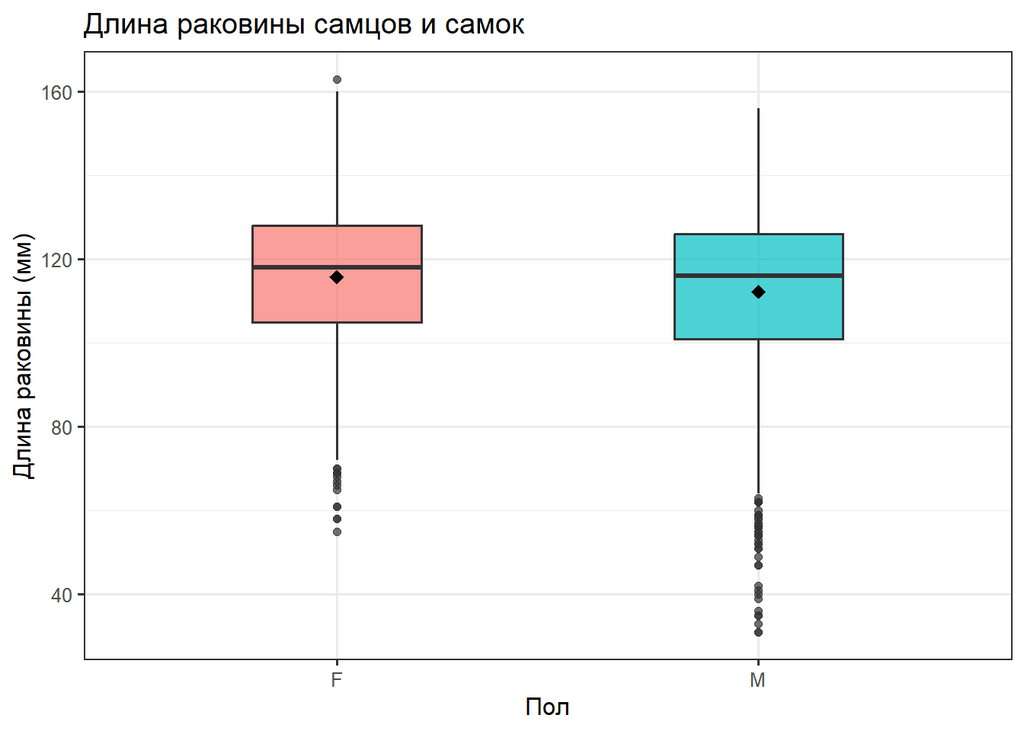

```r
# График
ggplot(subset_data, aes(x = Sex, y = Length, fill = Sex)) +
  geom_boxplot(width = 0.4, alpha = 0.7) +
  stat_summary(
    fun = mean,
    geom = "point",
    shape = 18,
    size = 3,
    color = "black"
  ) +
  labs(
    title = "Длина раковины самцов и самок",
    x = "Пол",
    y = "Длина раковины (мм)"
  ) +
  theme_bw(base_size = 12) +
  theme(legend.position = "none")
```

Распределения в обеих группах унимодальные, есть левосторонний хвост. Средняя длина раковины составляет 115 vs 112 мм у самое и самцов; медианы равны $118$ мм и $116$ мм соответственно. По графику распределения почти полностью перекрываются, визуально различие между группами выражено слабо.

### Задание 1.3

Выберите подходящий тип доверительного интервала и объясните, почему он соответствует исследовательскому вопросу.

Для проверки гипотезы выбран двусторонний 95%-й доверительный интервал для разности средних двух независимых выборок с поправкой Уэлча. Оно учитывает возможное неравенство дисперсий между популяциями.

### Задание 1.4

Постройте выбранный доверительный интервал для проверки поставленной гипотезы

```r
# t-тест Уэлча для M и F
len_M <- subset_data$Length[subset_data$Sex == "M"]
len_F <- subset_data$Length[subset_data$Sex == "F"]

test1 <- t.test(len_M, len_F, conf.level = 0.95)
test1$conf.int
```

```
[1] -4.931569 -2.149486
attr(,"conf.level")
[1] 0.95
```

### Задание 1.5

На основании доверительного интервала проверьте сформулированную гипотезу. Объясните результат и решение.

95%-й доверительный интервал для разности средних равен -4.93– -2.15 мм и смещен влево относительно нуля.. На уровне значимости $\alpha = 0.05$ мы отклоняем нулевую гипотезу $H_0$ в пользу альтернативной.

Что можно сказать о направлении и величине различия? Совпадает ли результат с вашим впечатлением от графика в задании 1.2? Как вы думаете, почему?

## 2. Сравнение массы съедобной части моллюска у самцов и самок

Исследователи предположили, что средняя масса съедобной части моллюска у самцов **больше**, чем у самок. Проверьте это предположение.

### Задание 2.1

Укажите, какой параметр генеральной совокупности вы оцениваете. Сформулируйте нулевую и альтернативную гипотезы.

> Обратите внимание на порядок вычитания средних: он определяет знак разности и её интерпретацию.

Сравним Разность генеральных средних массы съедобной части моллюска между самцами и самками:

- $H_0$: средняя масса съедобной части у самцов не превышает таковую у самок.
- $H_a$: средняя масса съедобной части у самцов больше, чем у самок.

### Задание 2.2

Выберите и рассчитайте описательные статистики, необходимые для исследования вопроса.

Визуализируйте распределения исследуемого признака у самцов и самок. Кратко опишите особенности распределений. Предположите по графикам, больше ли средняя масса съедобной части моллюска у самцов, чем у самок.

```r
subset_data$Sex <- droplevels(subset_data$Sex)

shuck_stats <- data.frame(
  Sex = c("F", "M"),
  N = as.vector(table(subset_data$Sex)),
  Mean = round(tapply(subset_data$Shucked_weight, subset_data$Sex, mean), 2),
  SD = round(tapply(subset_data$Shucked_weight, subset_data$Sex, sd), 2),
  Median = round(
    tapply(subset_data$Shucked_weight, subset_data$Sex, median),
    2
  ),
  IQR = round(tapply(subset_data$Shucked_weight, subset_data$Sex, IQR), 2)
)
print(shuck_stats, row.names = FALSE)
```

```
 Sex    N  Mean    SD Median   IQR
   F 1307 89.24 39.73  88.10 55.65
   M 1528 86.59 44.60  84.35 57.93
```

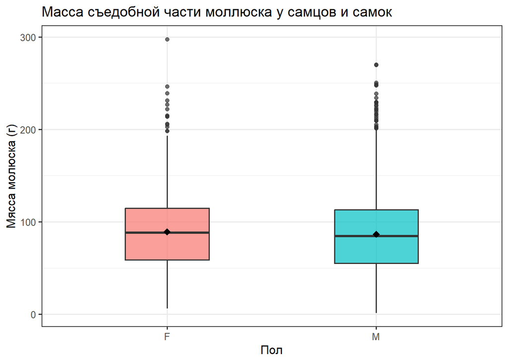

```r
ggplot(subset_data, aes(x = Sex, y = Shucked_weight, fill = Sex)) +
  geom_boxplot(width = 0.4, alpha = 0.7) +
  stat_summary(
    fun = mean,
    geom = "point",
    shape = 18,
    size = 3,
    color = "black"
  ) +
  labs(
    title = "Масса съедобной части моллюска у самцов и самок",
    x = "Пол",
    y = "Мясса молюска (г)"
  ) +
  theme_bw(base_size = 12) +
  theme(legend.position = "none")
```

Распределения в обеих группах скошены вправо. Средняя масса съедобной части у самок составляет 89.24 г, а у самцов — 86.59 г (медианы – 88.10 г и 84.35 г соответственно). По графикам средняя масса у самцов не выглядит больше, чем у самок.

### Задание 2.3

Выберите подходящий тип доверительного интервала и объясните, почему он соответствует исследовательскому вопросу.

Для проверки гипотезы, выбран односторонний нижний 95%-й доверительный интервал.

### Задание 2.4

Постройте выбранный доверительный интервал для проверки поставленной гипотезы

```r
shuck_M <- subset_data$Shucked_weight[subset_data$Sex == "M"]
shuck_F <- subset_data$Shucked_weight[subset_data$Sex == "F"]

test2 <- t.test(shuck_M, shuck_F, alternative = "greater", conf.level = 0.95)
test2$conf.int
```

```
[1] -5.254988       Inf
attr(,"conf.level")
[1] 0.95
```

### Задание 2.5

На основании доверительного интервала проверьте сформулированную гипотезу. Поддерживают ли данные заявленное предположение?

Односторонний 95%-й доверительный интервал для разности средних равен -5.25 и до + бесконечности и содержит ноль. На уровне значимости $\alpha = 0.05$ мы не отклоняем нулевую гипотезу $H_0$

Что можно сказать о направлении и величине различия? Совпадает ли результат с вашим впечатлением от графика в задании 2.2? Как вы думаете, почему?

## 3. Сравнение массы раковины незрелых особей и самок

Исследователи предположили, что средняя масса раковины *незрелых* особей **меньше**, чем у *самок*. Проверьте, поддерживают ли данные это предположение.

### Задание 3.1

Укажите, какой параметр генеральной совокупности вы оцениваете. Сформулируйте нулевую и альтернативную гипотезы.

- $H_0$: средняя масса раковины незрелых особей не меньше массы раковины самок.
- $H_a$: средняя масса раковины незрелых особей меньше, чем у самок.

### Задание 3.2

Выберите и рассчитайте описательные статистики, необходимые для исследования этого вопроса.

Визуализируйте распределения исследуемого признака у незрелых особей и самок. Кратко опишите особенности распределений. Предположите по графикам, меньше ли средняя масса раковины у незрелых особей, чем у самок.

```r
subset_data3 <- subset(rawdata_subset, Sex == "I" | Sex == "F")
subset_data3$Sex <- droplevels(subset_data3$Sex)

shell_summary <- data.frame(
  Группа = c("F (Самки)", "I (Незрелые)"),
  N = as.vector(table(subset_data3$Sex)),
  Среднее = round(tapply(subset_data3$Shell_weight, subset_data3$Sex, mean), 2),
  SD = round(tapply(subset_data3$Shell_weight, subset_data3$Sex, sd), 2),
  Медиана = round(
    tapply(subset_data3$Shell_weight, subset_data3$Sex, median),
    2
  ),
  IQR = round(tapply(subset_data3$Shell_weight, subset_data3$Sex, IQR), 2)
)
print(shell_summary, row.names = FALSE)
```

```
       Группа    N Среднее    SD Медиана   IQR
    F (Самки) 1307   60.40 25.13    59.0 32.35
 I (Незрелые) 1342   25.64 16.99    22.6 22.88
```

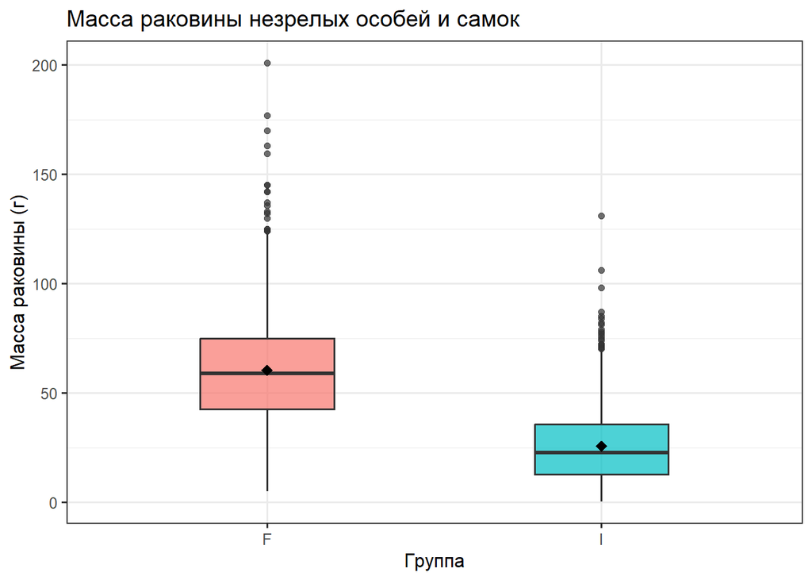

```r
ggplot(subset_data3, aes(x = Sex, y = Shell_weight, fill = Sex)) +
  geom_boxplot(width = 0.4, alpha = 0.7) +
  stat_summary(
    fun = mean,
    geom = "point",
    shape = 18,
    size = 3,
    color = "black"
  ) +
  labs(
    title = "Масса раковины незрелых особей и самок",
    x = "Группа",
    y = "Масса раковины (г)"
  ) +
  theme_bw(base_size = 12) +
  theme(legend.position = "none")
```

Выберите подходящий статистический критерий. Самостоятельно рассчитайте его наблюдаемую статистику и необходимые критические значения при заданном уровне значимости. Укажите критическую область.

Не используйте функции, выполняющие готовую проверку гипотез. Функции для вычисления квантилей распределений использовать можно. Вычислять p-значение в этом задании не нужно.

```r
#В этом чанке мне немного помог ИИ правильно задизайнить финальный вывод и определиться со списком переменных.
x_I <- subset_data3$Shell_weight[subset_data3$Sex == "I"]
x_F <- subset_data3$Shell_weight[subset_data3$Sex == "F"]


n_I <- length(x_I)
n_F <- length(x_F)
m_I <- mean(x_I)
m_F <- mean(x_F)
v_I <- var(x_I)
v_F <- var(x_F)


se <- sqrt(v_I / n_I + v_F / n_F)


t_statistic <- (m_I - m_F) / se

degrees_of_freedom <- (v_I / n_I + v_F / n_F)^2 /
  ((v_I / n_I)^2 / (n_I - 1) + (v_F / n_F)^2 / (n_F - 1))

t_critical <- qt(0.05, df = degrees_of_freedom)

cat(" t-статистика:", round(t_statistic, 4), "\n")
```

```
 t-статистика: -41.6078
```

```r
cat("Критическое значение:", round(t_critical, 4), "\n")
```

```
Критическое значение: -1.6455
```

```r
cat("Критическая область: (-Inf; ", round(t_critical, 4), "]\n", sep = "")
```

```
Критическая область: (-Inf; -1.6455]
```

```r
t.test(x_I, x_F, alternative = "less") # Точно такое же значение t!
```

```
    Welch Two Sample t-test

data:  x_I and x_F
t = -41.608, df = 2286, p-value < 2.2e-16
alternative hypothesis: true difference in means is less than 0
95 percent confidence interval:
      -Inf -33.39063
sample estimates:
mean of x mean of y
 25.63644  60.40199
```

### Задание 3.4

На основании полученных результатов сформулируйте вывод относительно нулевой гипотезы и обоснуйте своё решение. Поддерживают ли данные предположение исследователей?

Наблюдаемое значение тестовой статистики t = -41.6078 и падает глубоко в критическую область: На уровне значимости $\alpha = 0.05$ мы отклоняем нулевую гипотезу $H_0$ в пользу альтернативной.

Что можно сказать о направлении и величине различия? Совпадает ли результат с вашим впечатлением от графика в задании 3.2? Как вы думаете, почему?

Направление и величина: разность средних отрицательна и составляет -34.77 г. Раковина молоди более чем в два раза легче раковины взрослых самок.